# Relatório 1 — Introdução aos conceitos demográficos

# Introdução

Neste relatório foi feita uma breve descrição dos resultados de uma pesquisa demográfica acerca do Estado do Espírito Santo. Foram analisados os dados referentes à faixa etária e sexo para visualização de gráficos como pirâmides etárias e cálculo de índice de dependência.

O objetivo desta pesquisa era chegar, por conta própria, em visualizações gráficas que refletissema realidade, coletando dados e realizando cálculos de forma cuidadosa. Durante duas aulas, também estudando conceitos de estatística demográfica, como pirâmides etárias e índice de dependência, que foram usados para entender como a população do Estado em questão evoluiu desde o ano de 1991.

Os dados usados nesta análise podem ser encontrados clicando [aqui](https://datasus.saude.gov.br/informacoes-de-saude-tabnet/).

Além disso, abaixo estão as tabelas usadas nesta análise, referentes à população masculina, feminina e total separadas por faixa etária em cada ano.

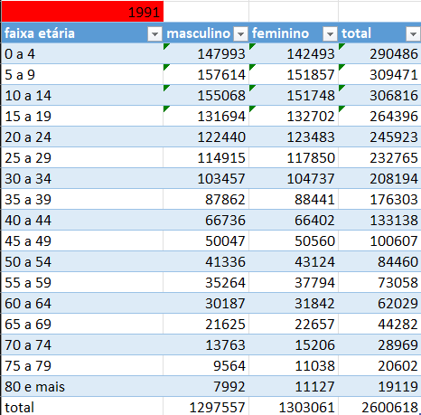

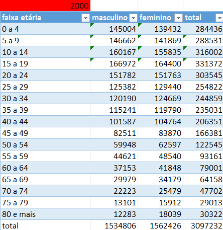

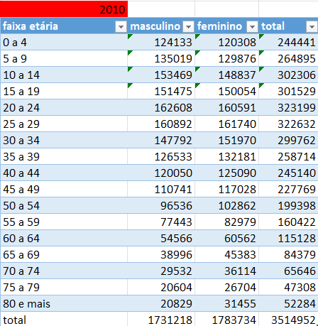

# Pirâmides etárias

É esperado, em todo o mundo, que a população idosa aumente cada vez mais, devido a fatores como melhores condições de vida, avanço na medicina, entre outros. Além disso, há uma forte tendência de decrescimento da população, isto é, as pessoas estão tendo cada vez menos filhos, o que diminui a taxa de fecundidade.

Desse modo, é esperado que de 1991 a 2010 vejamo um crescimento expressivo do topo da pirâmide, que representa a população mais idosa, enquanto a base da pirâmide deve diminuir levemente.

### 1991

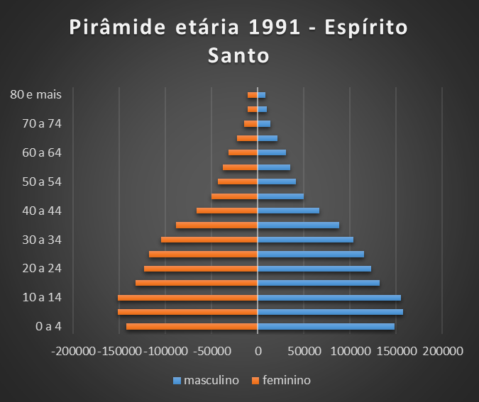

### 2000

Nos anos 2000, já era claro que a população iria parar de crescer em algum momentos — mesmo que apenas décadas à frente. No caso deste gráfico, o que chama mais atenção ainda não é necessariamente a população idosa, mas sim a diferença entre crianças e adultos. Podemos ver que a proporção entre crianças de 0-9 anos e jovens de 10-34 anos se alterou, mostrando que de fato a populção infantil tem diminuído.

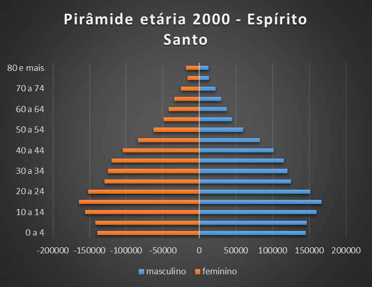

### 2010

Neste ano é onde temos uma mudança mais expressiva, não só a proporção entre adultos e crianças mudou, como temos mais idosos, i.e, o topo da pirâmide ficou mais largo. Como citado no início, há várias razões para isto, desde avanços na medicina a melhores condições de saúde pública — como saneamento básico.

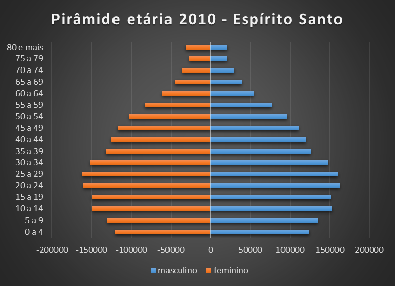

# Faixa etária por ano

Também podemos ver no gráfico abaixo como a proporção de idosos aumentou ao longo dos anos, além da proporção geral de cada faixa etária. Apesar de aqui a mudança não ser tão visualmente expressiva como nas pirâmides etárias, o que mais chama atenção neste caso é a diminuição da população infantil (0-14 anos), deixando clara a tendência de ser ter cada menos filhos.

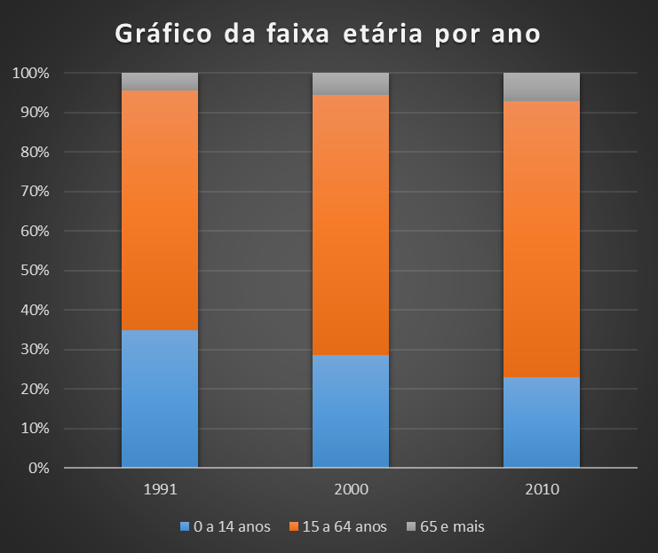

# Índice de dependência

E por último, uma outra métrica importante é o índice de dependência, que diz o quanto uma certa população (não ativa) depende da população ativa (15 - 64 anos).

Podemos calcular 3 razões de dependência, a de jovens, idosos e a total, definida pela soma das duas primeiras, como mostram as fórmulas abaixo.

### Índice de dependência de jovens

Esta razão nos diz a proporção de jovens dependentes da população ativa, isto é, a proporção de jovens que dependem da população ativa atualmente.

$$IDJ=\left(\frac{população\ 0\ a\ 14\ anos}{População\ 15\ a\ 64\ anos}
\right)\times 100$$

### Índice de dependência de idosos

Neste caso, temos a proporção para os idosos.

$$IDI=\left(\frac{população\ 65\ anos\ e\ mais}{População\ 15\ a\ 64\
anos} \right)\times 100$$

### Índice de dependência total (IDT)

E aqui, é calculada a proporção total do índice de dependência, ou seja, a proporção do total de jovens de 0 a 14 anos e idosos com mais de 65 anos que dependem da população atualmente ativa.

$$IDJ=\left(\frac{população\ 0\ a\ 14\ anos}{População\ 15\ a\ 64\ anos}
\right)\times 100\quad +\quad IDI=\left(\frac{população\ 65\ anos\ e\
mais}{População\ 15\ a\ 64\ anos} \right)\times 100$$

Abaixo, podemos ver como o índice de dependência variou entre 1991, 2000 e 2010 para jovens idosos, e para o total (%).

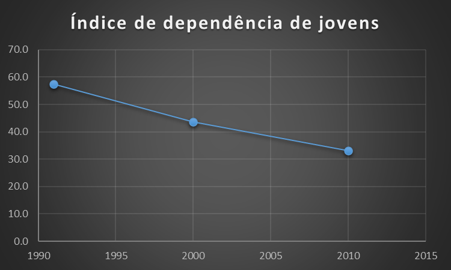

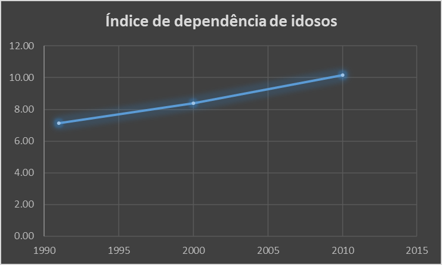

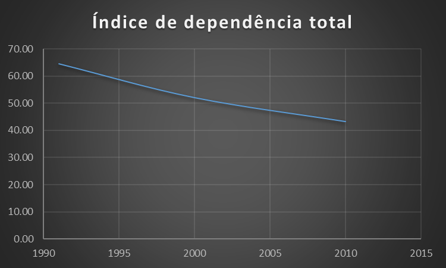

### O que isso nos diz

Ao ver estes gráficos, fica claro o que foi discutido anteriormente. A população jovem está diminuindo e a população idosa, aumentando. Além disso, é interessante notar que a população jovem está diminuindo mais rápido do que a população idosa está crescendo, e podemos confirmar isso ao calcular o índice de dependência total, visto que ele decresceu, ou seja, dado que o gráfico de IDJ decaiu e o de IDI cresceu, da mudança dominante foi o decrescimento.

A um primeiro olhar o IDT (índice de dependência total) pode parecer um ótimo sinal, pois faz parecer que a população ativa está aumentando, porém isso seria um grande erro, visto que o que diminuiu (a população infantil) deveria ser a futura população ativa! Com isso, é possível até mesmo, em um dos piores cenários, esperar um colapso do sistema de aposentadoria atualmente em exercício no Brasil, além de impostos mais altos no futuro, para tentar compensar a menor população trabalhista.

# Conclusão